# FIFA 19 Data Analysis

## by Ahmad Sherief

## Investigation Overview

The goal of this presentation is to answer some intriguing questions about FIFA 19 players. Some of which are:

- Which positions do football players play in the most?
- Which clubs have the top 100 world class players?
- Which clubs pay the highest salaries?
- On average, who has a higher value, a left or a right foot player?
- How are the skill moves distributed between left and right foot players?
- Do a player height and weight affect his balance?
- How can ball control affect the player dribbling skills? Are those releated to the skill moves?
- For each player role, how does the player positioning affect his finishing skills? Does the player skill moves and international reputation affect the previous results?

## Dataset Overview

This dataset contains detailed attributes for every player registered in the latest edition of FIFA 19 database.

### What is the structure of your dataset?

The dataset initially contained 18207 records with 89 features, after some data wrangling, only 57 features are selected and 48 entries were dropped giving a 18159 by 57 dataframe.

### What is/are the main feature(s) of interest in your dataset?

The main features on interest are the player value, wage and overall.

### What features in the dataset do you think will help support your investigation into your feature(s) of interest?

The player's age, potential, club, skill moves, and other qualities like dribbiling rating, balance rating, shot power rating, and so on.

## Which positions do football players play in the most?

We can see that the striker position (ST) has the most players followed by the goal keeper position (GK) while the least positions are the RF and LF, this may be because most team formations don't include the RF or LF positions, instead they prefere to have RW and LW or any other formation.

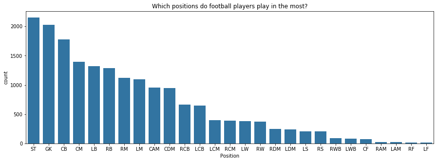

```python
plt.figure(figsize = (15,5))
base_color = sb.color_palette()[0]
position_ordered = df['Position'].value_counts().index
sb.countplot(data=df, x='Position',color = base_color, order = position_ordered);
plt.title('Which positions do football players play in the most?');
```

## Which clubs have the top 100 world class players?

Real Madrid comes first with the highest number of top class players, which is 11 players, followed by Juventus, FC Barcelona, and Manchester City, who all have 10 top class players.

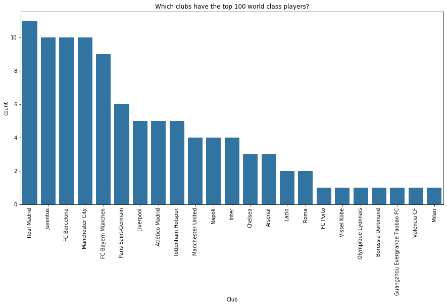

```python
plt.figure(figsize=(15,7))
order = df.nlargest(100, 'Overall').Club.value_counts().index
sb.countplot(data = df.nlargest(100, 'Overall'), x = 'Club', order=order, color=base_color);
plt.xticks(rotation=90);
plt.title('Which clubs have the top 100 world class players?');
```

## Which clubs pay the highest salaries?

As expected, we can see that Real Madrid, which we saw before that it has the highest number of top class players, pays the highest salaries, followed by FC Barcelona, then Juventus, and Manchester City.

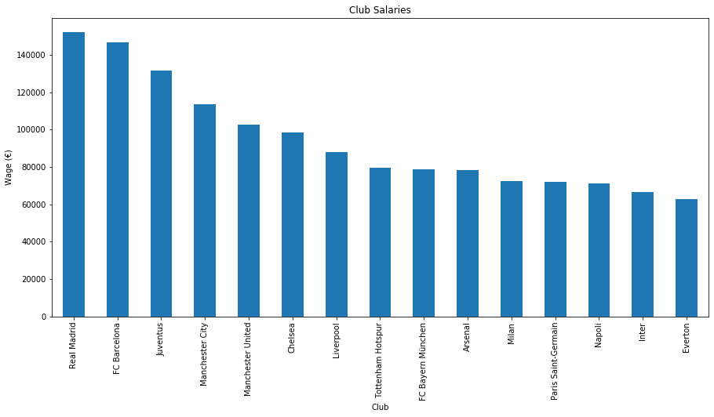

```python
plt.figure(figsize=(15, 7))
df.groupby(['Club'])['Wage'].mean().sort_values(ascending=False)[:15].plot(kind='bar');
plt.ylabel('Wage (€)');
plt.xticks(rotation=90);
plt.title('Club Salaries');
```

## On average, who has a higher value, a left or a right foot player?

After removing outliers, it can be seen that left foot players on average have higher value than right foot players.

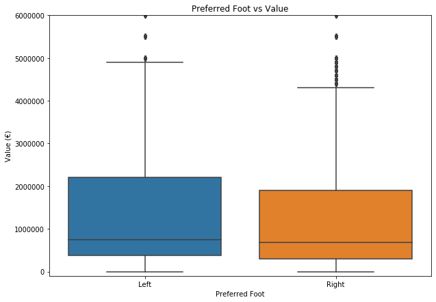

```python
plt.figure(figsize=(10, 7))

sb.boxplot(data = df, x='Preferred Foot', y='Value');
plt.title("Preferred Foot vs Value");
plt.ylabel('Value (€)')
plt.ylim([-100000,6000000]);
```

## How are the skill moves distributed between left and right foot players?

We can see that the ratio of level 2 and level 5 skill moves players is almost the same in the right and left foot players. However, it is clearly seen that left foot players are more in the 3 and 4 skill moves level than those in the right foot players. This can be an indicator that left foot players are generally more skilled than right foot ones.

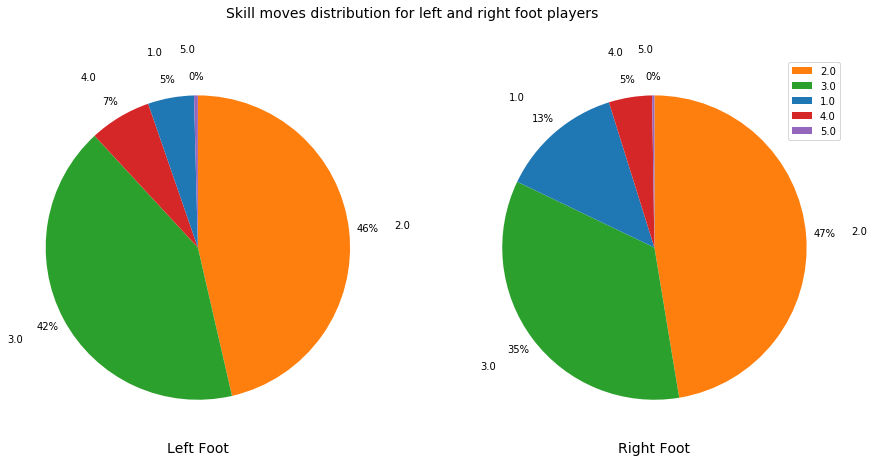

```python
plt.figure(figsize=(15,7))
fig = plt.gcf()
fig.suptitle("Skill moves distribution for left and right foot players", fontsize=14)

# define colors to map the same skill moves category to the same color
colors = {
    '1.0': 'C0',
    '2.0': 'C1',
    '3.0': 'C2',
    '4.0': 'C3',
    '5.0': 'C4'
}
# left skills
left_skills = df[df['Preferred Foot'] == 'Left'].groupby('Skill Moves')['Preferred Foot'] \
.count().sort_values(ascending=False);

# right skills
right_skills = df[df['Preferred Foot'] == 'Right'].groupby('Skill Moves')['Preferred Foot'] \
.count().sort_values(ascending=False)

plt.subplot(1,2,1)
left_skills.plot(kind = 'pie',startangle = 90, counterclock = False, autopct='%1.0f%%', pctdistance=1.12, \
                 labeldistance=1.3, colors=[colors[str(key)] for key in list(left_skills.index)]);
plt.ylabel('');
plt.xlabel('Left Foot',fontsize=14);


plt.subplot(1,2,2)
right_skills.plot(kind = 'pie',startangle = 90, counterclock = False, autopct='%1.0f%%', pctdistance=1.12, \
                  labeldistance=1.3, colors=[colors[str(key)] for key in list(right_skills.index)]);
plt.ylabel('');
plt.xlabel('Right Foot',fontsize=14);
plt.legend(('2.0','3.0','1.0','4.0','5.0'));
```

## Do a player height and weight affect his balance?

We observe that players will high balance tend to be short and light, while tall and heavy players tend to have less balance.

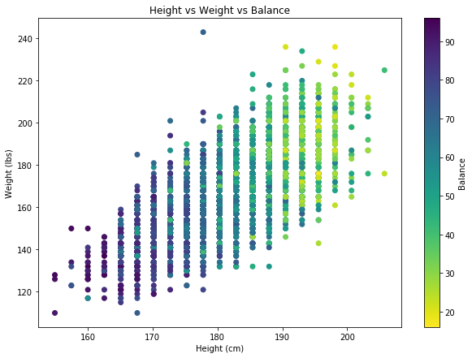

```python
plt.figure(figsize=(10,7))
plt.scatter(data=df, x = 'Height',y='Weight',c='Balance',cmap='viridis_r');
plt.colorbar(label = 'Balance')
plt.xlabel('Height (cm)')
plt.ylabel('Weight (lbs)');
plt.title('Height vs Weight vs Balance');
```

## How can ball control affect the player dribbling skills? Are those releated to the skill moves?

We can see that there is a linear relationship between the dribbling and the ball control skills, as the player ball control skills increase, so does his dribbling skills. Moreover, we can see that players with low dribbling and ball control have lower skill moves, and those with high dribbling and ball control skills have high skill moves.

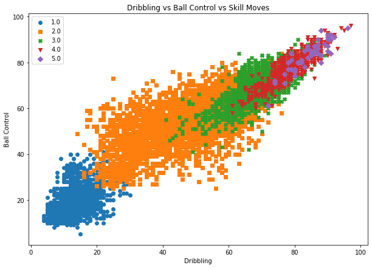

```python
plt.figure(figsize=(10,7))
cat_markers = [[1.0, 'o'],
               [2.0, 's'],
               [3.0, 'X'],
               [4.0, 'v'],
               [5.0, 'D'],]

for cat, marker in cat_markers:
    df_cat = df[df['Skill Moves'] == cat]
    plt.scatter(data = df_cat, x = 'Dribbling', y = 'BallControl', marker = marker)
plt.legend(['1.0','2.0','3.0','4.0','5.0']);
plt.xlabel('Dribbling')
plt.ylabel('Ball Control');
plt.title('Dribbling vs Ball Control vs Skill Moves');
```

## Positioning vs Finishing vs Skill Moves vs International Reputation vs Role

#### For each player role, how does the player positioning affect his finishing skills? Does the player skill moves and international reputation affect the previous results?

As we can see, there is generally a linear relationship between the player positioning and his finishing skills, the better a player can position himself, the more chances he can get to score goals.

It can also be seen that this linear relationship increases as the skill moves category increases, this is can be seen as the points come closer together. This event also occures as the player role changes, so for the defence role, the linear relationship is weak, then it is stronger in the midfield role, and is strongest in the attacking role.

Finally, we can see that the international reputation increases with the increase in skill category, as seen by reduction in the blue color, and with the increase in positioning and finishing.

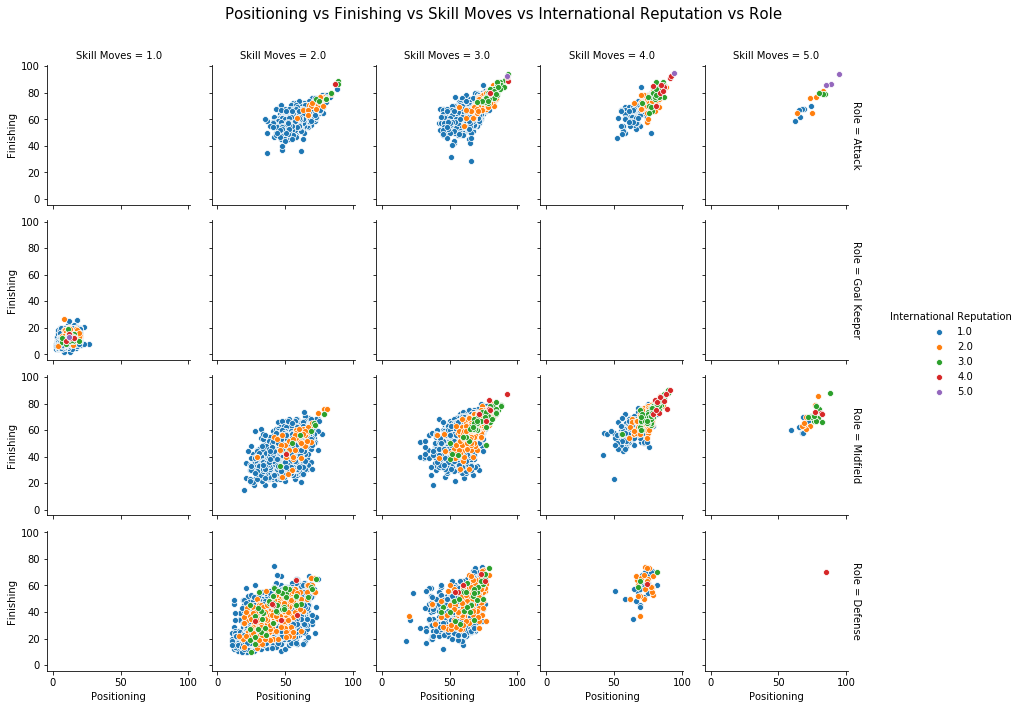

```python
g = sb.FacetGrid(data = df, col = 'Skill Moves', row = 'Role', hue='International Reputation', height = 2.5,
                margin_titles = True)
g.map(sb.scatterplot, 'Positioning', 'Finishing');
g.add_legend();
plt.subplots_adjust(top=0.9)
g.fig.suptitle('Positioning vs Finishing vs Skill Moves vs International Reputation vs Role',fontsize=15);
```